# Comparison of the Exponential Distribution and the Central Limit Theorem

John Slough II

8 Jan 2015

We were asked to investigate the exponential distribution and compare it with the Central Limit Theorem (CLT).  
First I will show two plots that show the theoretical mean and variance of the exponential distribution, compared with the cumulative means and variances. This is a very good way to see the CLT at work. Second, I will show a histogram of the empirical values of the 40 means of the exponential distribution and superimpose the normal curve over that data. This will give a good idea of whether or not the distribution is normal. Lastly, I will show a QQ plot of the data with the Normal line.

```r
set.seed=1234
lambda=.2
n=40
nsim=1000

expdist = rep(NA,nsim)

for (i in 1:nsim){
  expdist[i] = mean(rexp(n,lambda))
}

empiricalmean=mean(expdist)
theoreticalmean=1/lambda

empiricalvariance=var(expdist)
theoreticalvariance=1/((lambda^2)*n)

cumulativemean=cumsum(expdist) / seq_along(expdist)
cumvar=cumsum((expdist-empiricalmean)^2)/(seq_along(expdist)-1)
```

I ran a simulation of 40 samples for the exponential distribution, and took the mean of each sample. This was iterated 1000 times. I obtained an empirical mean of 4.9884813. The theoretical mean is just 1/lambda, where lambda=0.2. The result is 5. As you can see, they are almost identical. The empirical variance is 0.6151202 and the theoretical variance is 0.625, obtained by the formula (1/lambda^2)/n. They are also very similar.

The following plot shows the cumulative emperical means of the samples of 40 exponentially distributed values. According to the CLT, these should converge to the theoretical mean, and we do see this happening as the iterations increase.

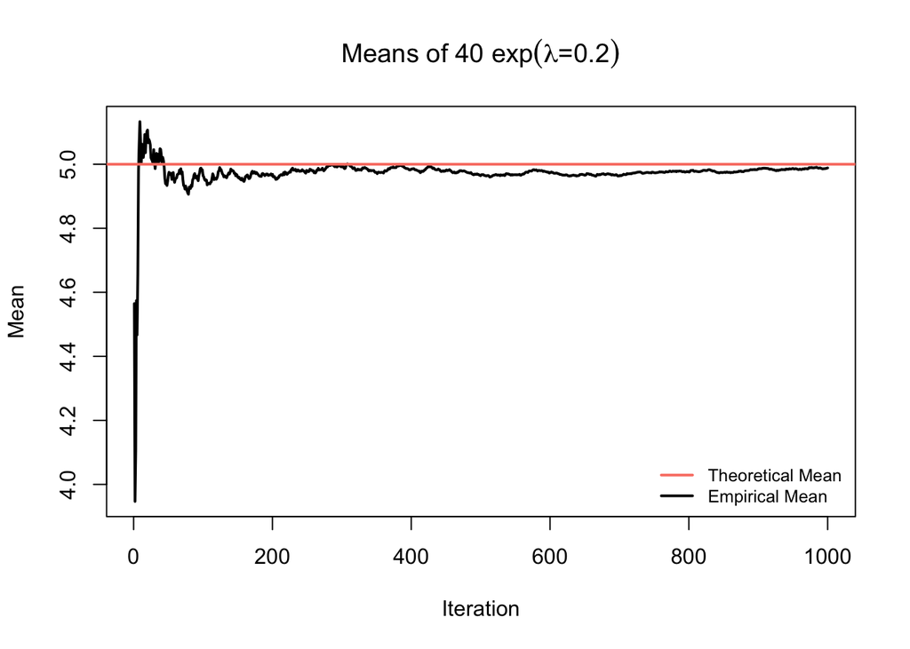

```r
plot(seq_along(expdist),cumulativemean,type="l",lty=1,lwd=2,
     main=expression("Means of 40 exp"(lambda*"=0.2")),xlab="Iteration"
     ,ylab="Mean")
abline(h=theoreticalmean,col="salmon",lwd=2)
legend("bottomright", legend=c("Theoretical Mean","Empirical Mean"),
       col=c("salmon","black"), lty=c(1,1),lwd=c(2,2),cex=.8,bty="n")
```

The next plot is similar to the previous one, however it shows the variances of the means of the 40 exponentially distributed values. As with the previous plot, the more iterations, the closer the emperical variance gets to the theoretical variance.

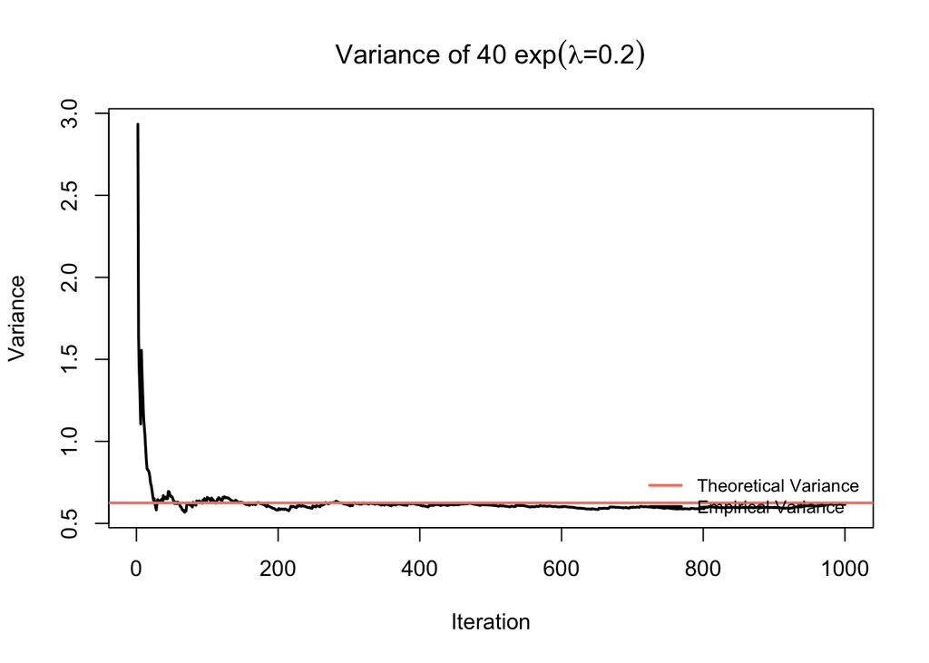

```r
plot(seq_along(expdist),cumvar,type="l",lty=1,lwd=2,
     main=expression("Variance of 40 exp"(lambda*"=0.2")),
     xlab="Iteration",ylab="Variance")
abline(h=theoreticalvariance,col="salmon",lwd=2)
legend("bottomright", legend=c("Theoretical Variance",
                               "Empirical Variance"),
       col=c("salmon","black"), lty=c(1,1),lwd=c(2,2),cex=.8,bty="n")
```

The following plot shows a histogram of the data. We can see the theoretical distribution superimposed over the histogram. The empirical distribution appears to approximate the normal distribution very well.

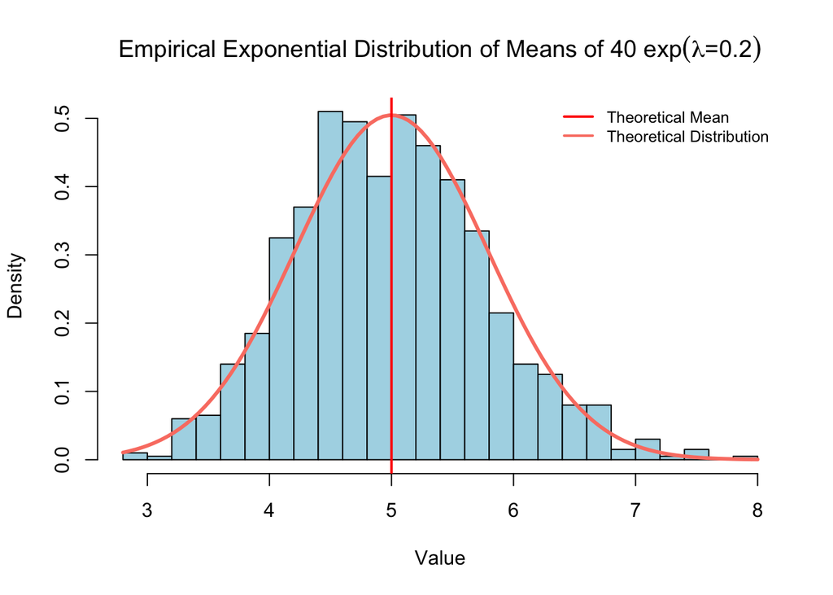

```r
x=seq(0,8,0.01)
hist(expdist,breaks=25,freq=FALSE,col="lightblue",main=expression("Empirical Exponential Distribution of Means of 40 exp"(lambda*"=0.2")),xlab="Value",ylab="Density")
curve(dnorm(x, mean=theoreticalmean, sd=sqrt(theoreticalvariance)),
      add=TRUE,lwd=3,col="salmon")
abline(v=theoreticalmean,lwd=2,col="red")
legend("topright", legend=c("Theoretical Mean","Theoretical Distribution"),
       col=c("red","salmon"), lty=c(1,1),lwd=c(2,2),cex=.8,bty="n")
```

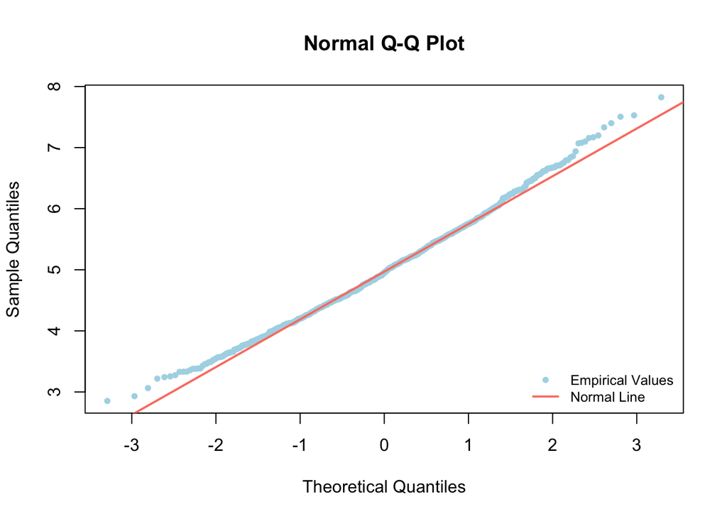

```r
qqnorm(expdist,pch=16,cex=.8,col="lightblue")
qqline(expdist,col="salmon",lwd=2)
legend("bottomright", legend=c("Empirical Values","Normal Line"),
       col=c("lightblue","salmon"),pch=c(16,NA),
       lwd=c(NA,2),lty=c(NA,1),cex=.8,bty="n")
```

**Conclusion**

From the above plots, we can see that as the iterations increase, the empirical means and variances tend to the theoretical mean and variance. Also, the distribution of the mean is approximately normal. The is essentially what the CLT states should occur.